# 1st practice

Markdown - RMarkdown

Daniel Calenzani

2022/11/29

## General considerations:

We’ve divided the analysis in 6 steps, using the guide proposed by Rebecca Bevans in [Linear Regression in R - A Step-by-Step Guide & Examples](https://www.scribbr.com/statistics/linear-regression-in-r/)

```r
library(ggplot2)
library(dplyr)
library(broom)
library(ggpubr)
library(tidyverse)
library(readr)
library(haven)
```

## Linear Regression with numeric VI

### Step 1: Load the data into R

```r
# Load the database

data_at <- read_sav("db_censo_comisarias.sav")
summary(data_at)
```

[output not shown]

[output cut: 145 more lines]

```
##  Min.   :0.00000   Min.   :0.000000   Min.   :0.0000   Min.   :0.00000
##  1st Qu.:0.00000   1st Qu.:0.000000   1st Qu.:0.0000   1st Qu.:0.00000
##  Median :0.00000   Median :0.000000   Median :0.0000   Median :0.00000
##  Mean   :0.00981   Mean   :0.001177   Mean   :0.2867   Mean   :0.02758
##  3rd Qu.:0.00000   3rd Qu.:0.000000   3rd Qu.:1.0000   3rd Qu.:0.00000
##  Max.   :1.00000   Max.   :1.000000   Max.   :1.0000   Max.   :1.00000
##
##   AT109_19_O         Factor_2016      Factor_2017
##  Length:68811       Min.   : 1.000   Min.   : 1.00
##  Class :character   1st Qu.: 1.000   1st Qu.: 1.00
##  Mode  :character   Median : 1.293   Median : 1.00
##                     Mean   : 2.912   Mean   : 2.00
##                     3rd Qu.: 3.080   3rd Qu.: 1.95
##                     Max.   :19.760   Max.   :12.05
##                     NA's   :28751    NA's   :40060
```

### Step 2: Explore outcome variable (must be numeric)

We checked if the independent variable `automoviles involucrados` (VI - AT_106_1) is numeric. A general look at the database shows that this number represents only the value for cars of sedan or hatchback models, while other automobiles such as trucks, station wagons, buses or vans are excluded from this count.

For practice purposes we’ll consider it as a numeric variable, as the analysis with categoric variables omits many of the interpretations in a numeric variable.

```r
heridos <- data_at$AT108_2
vehiculos <- data_at$AT106_1_CANT

glimpse(heridos) #Numeric
```

```
##  num [1:68811] NA 2 NA 1 1 1 0 NA 1 1 ...
##  - attr(*, "label")= chr "NÚMERO DE HERIDOS"
##  - attr(*, "format.spss")= chr "F11.0"
##  - attr(*, "display_width")= int 11
```

```r
glimpse(vehiculos) #Numeric
```

```
##  num [1:68811] 1 1 NA NA NA 1 1 NA NA NA ...
##  - attr(*, "label")= chr "VEHÍCULO MAYOR  AUTOMÓVIL - CANTIDAD"
##  - attr(*, "format.spss")= chr "F11.0"
##  - attr(*, "display_width")= int 11
```

## Step 3: Make sure data assumptions

#### A. Linearity

When checking for linearity we can see that the points are not scattered in a linear distribution, they form columns for each whole value. They miss the mark in forming some sort of bell curve and most of the cases had only 1 automobile involved.

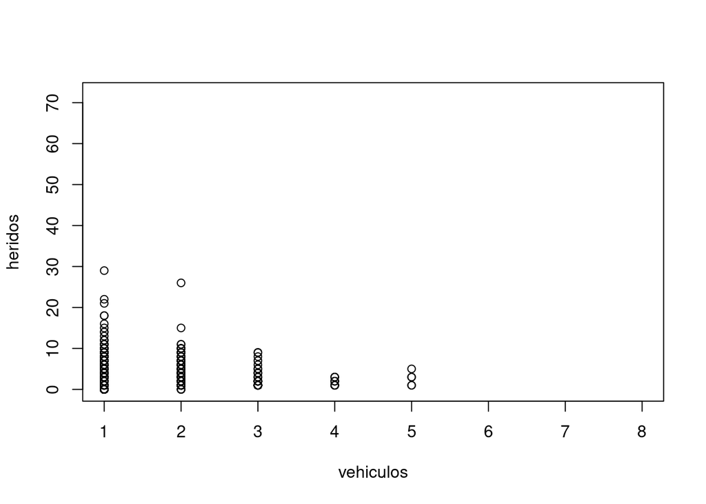

```r
plot(heridos ~ vehiculos, data = data_at)
```

#### B. Independence of observations

Theoretically, we expect each variable to be independent

#### C. Normality

When checking for normality, the histogram is not bell shaped, which states a tendency of values in the lower numbers of the independent variable. Most of the cases had 1 or 2 automovile vehicles involved.

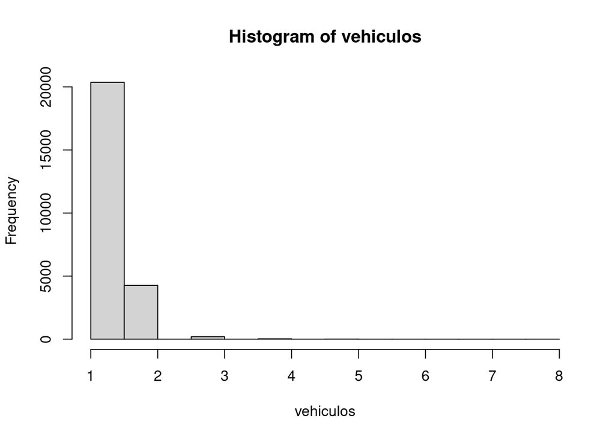

```r
hist(vehiculos)
```

```r
# Se puede evaluar la normalidad por  QQplot, Kurtosis
```

## Step 3: Perform the linear regression analysis

However, if we treat the variables as categorical ones, we can omit the linearity analysis and insist on this relation without trouble.

```r
data_at_lm <- lm(heridos ~ vehiculos, data = data_at)

summary(data_at_lm)
```

```
##
## Call:
## lm(formula = heridos ~ vehiculos, data = data_at)
##
## Residuals:
##     Min      1Q  Median      3Q     Max
## -2.3146 -0.5449 -0.5449  0.4551 27.4551
##
## Coefficients:
##             Estimate Std. Error t value Pr(>|t|)
## (Intercept)  1.10247    0.03667   30.06   <2e-16 ***
## vehiculos    0.44243    0.03089   14.32   <2e-16 ***
## ---
## Signif. codes:  0 '***' 0.001 '**' 0.01 '*' 0.05 '.' 0.1 ' ' 1
##
## Residual standard error: 1.307 on 13116 degrees of freedom
##   (55693 observations deleted due to missingness)
## Multiple R-squared:  0.0154, Adjusted R-squared:  0.01533
## F-statistic: 205.2 on 1 and 13116 DF,  p-value: < 2.2e-16
```

## Step 4: Check the homocedasticity

Residuals show bias, as they are distributed between the two first values. If we consider the “vehicles” variable as categorical then we can also omit this test

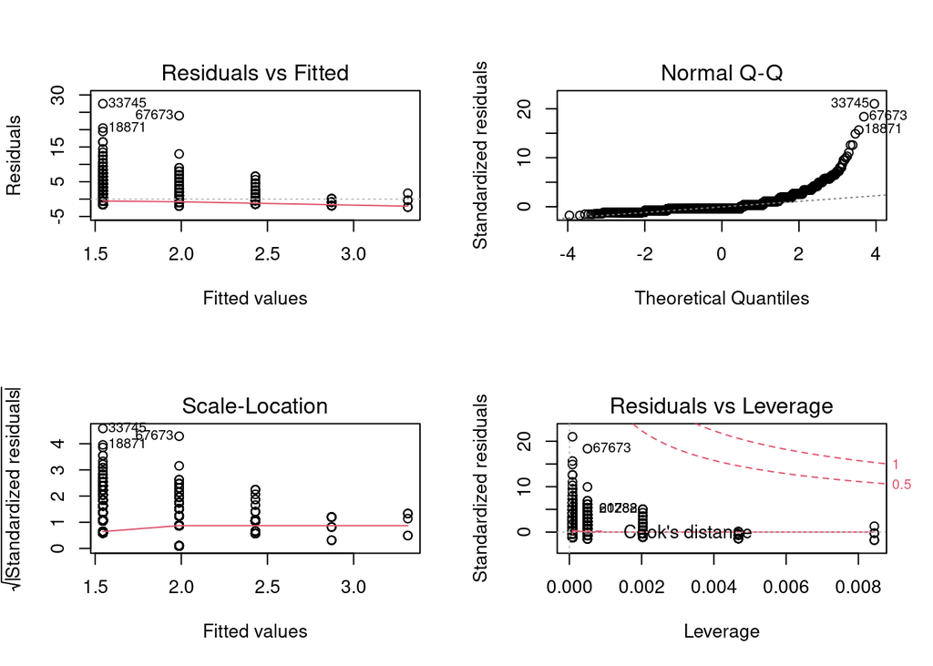

```r
par(mfrow=c(2,2))
plot(data_at_lm)
```

```r
par(mfrow=c(1,1))
```

## Step 5: Perform a graph to visualize the results

With the previous steps done we can graph the linear model an see that the number of vehicles involved has (eventhough small) a relation to the number of peopler hurt in the accident

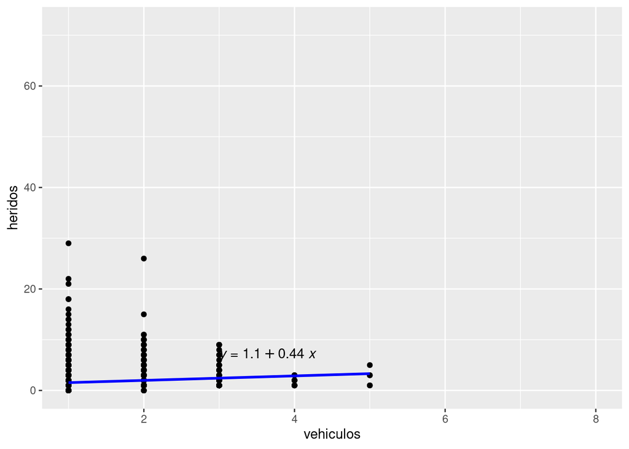

```r
graph <- ggplot(data_at, aes(x=vehiculos, y=heridos)) + geom_point()
graph <- graph + geom_smooth(method='lm', col='blue')
graph <- graph + stat_regline_equation(label.x = 3, label.y = 7)
graph
```

```r
relation <- lm(vehiculos~heridos)
# give the chart a name
png(file = "linearregression.png")
# Plot
plot(vehiculos,heridos, col = "blue", main = "Regresión de vehículos y heridos en choques de autos",
abline(lm(vehiculos~heridos)), cex = 1.3, pch = 16, xlab = "vehiculos", ylab = "heridos")
# Save
dev.off()
```

## Step 6: Report and interpret your results

We can interpret of this analysis that the number automovile vehicles invovled in car accidents have a relation with the number of wounded people. In our next analysis we will sum the number of different types of vehicles involved, so we can get a complete picture of the relation between vehicles involved and total number of wounde people.

We will also try to create an html site where you can select the type of vehicle you wish to add in the analysis